# How To Write a Post

Hello, Fellow Stats Blogger!

Say one desires to post to this venerable blog. How would you do that?

## Step 1:

**Fork the repo:**

Go to github.com/nstrayer/nashvilleBioStats and fork the repository (upper right corner).

[output not shown]

Now get into the newly deposited repository (`cd nashvilleBioStats`). Once inside of this repo really only one thing matters and that is the `_source` directory. If you navigate inside of it you will see that there are a bunch of `.Rmd` files in it. This is where the magic happens.

## Step 2:

**Make a new post:**

At this point you could just generate a new `Rmd` in anyway you desire, but for the sake of sanity I would suggest copying an existing one in the `_source/` directory as the header is a tad bit different than what you probably have used before. (Alternatively you could just start from scratch and make sure to copy in the top of an already used file.)

### File Naming:

This is important. The name of the file you use helps the blog know information about it. You must start the file name with the date in the format `year-month-day-postTitle.Rmd`.

For example: if I were to create a simple post I would do the following in the terminal.

```bash
cd nashvilleBioStats/_source
cp 2015-12-19-howTo.Rmd 2015-12-20-newPost.Rmd
rStudio 2015-12-20-newPost.Rmd
```

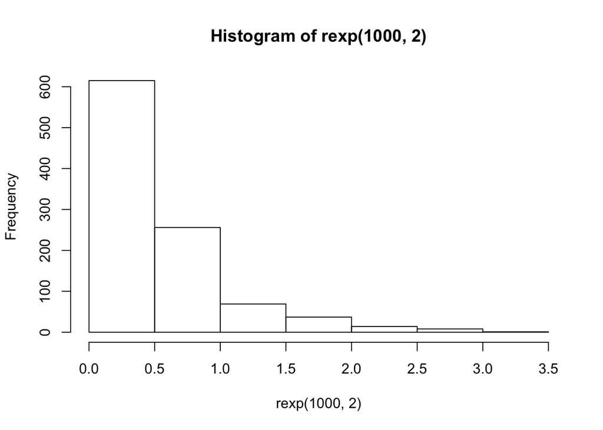

```r
hist(rexp(1000, 2))
```